# Module2

Wilson FOTSING Wilfried Armel N’GUESSAN Vamoussa DIABATE Laurent Fabrice NGWE Iantsa Marie-Anne RANDRIANARIVONY

date** : 2025-01-27

## Statistiques descriptives

### Exercice 1

calculons la moyenne et variance, que remarquez-vous? Pourquoi?

```r
x <- rnorm(100)

#Calculons la moyenne

mean(x)
```

```
## [1] 0.05455169
```

```r
#Calculons la variance

var(x)
```

```
## [1] 1.186085
```

On remarque que les valeurs de la moyenne et de la variance calculées sur un échantillon ne sont pas égales aux valeurs théoriques.

( **moyenne= 0.05** et **variance 1.19** )

pour n=100, Ces résultats s’écartent de ceux attendus à cause du biais d’échantillonage.

- Augmenter le nombre d’observation dans la fonction rnorm() qui génère des données d’une loi normale, que se passe t-il?

```r
y <- rnorm(10000)

#Calcul de la moyenne

mean(y)
```

```
## [1] -0.00301921
```

```r
#Calcul de la variance

var(y)
```

```
## [1] 0.995821
```

**moy = 0**

**var = 1**

En augmentant le nombre d’observation a n=10000 nous remarquons que les résultats se rapprochent des valeurs théoriques (moyenne=0 et variance=1).

### Exercice 2

Construire une fonction qui permet de représenter la distribution d’une série de données.

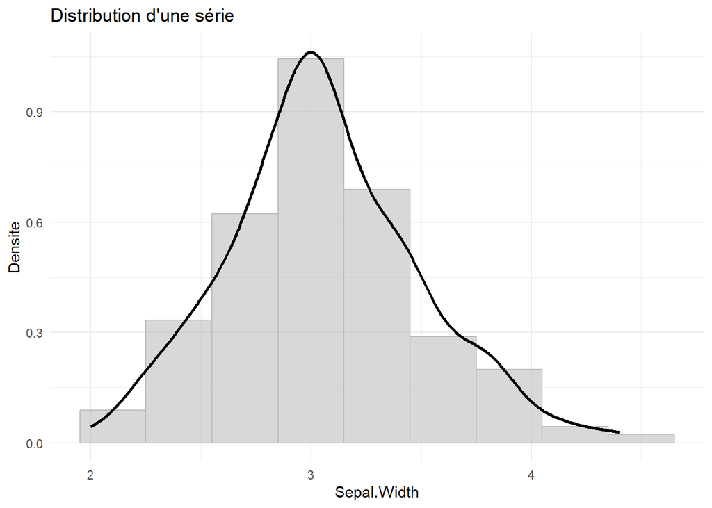

```r
#la fonction

plot_distribution <- function(data, variable, title = "Distribution d'une série ",couleur="grey")

  #Création du graphique

  ggplot(data, aes_string(x = variable)) +
  geom_histogram(aes(y = ..density..),
                   binwidth = 0.3,         # Largeur des barres
                   fill = couleur,           #Couleur des barres
                   alpha = 0.6,            #Transparence des barres
                   color = "grey" ) +      #Bordure des barres
    geom_density(color = "black", size = 1) + #Courbe de densité
    labs(title = title, x = variable, y = "Densite") + #Titre et étiquettes des axes
    theme_minimal()                         #Thème visuel simple

plot_distribution(iris, "Sepal.Width")
```

### Exercice 3

```r
x <- rnorm(100)

y <- x * x

#Calcul de la corrélation

correlation <- cor(x, y)
cor(x, y)
```

```
## [1] 0.08774638
```

**cor(x,y)= 0.09**

Cette valeur exprime une faible corrélation linéaire entre x et y.

### Exercice 4

```r
vehicule <- read.csv("Dataset 1.csv")
head(vehicule)
```

```
##   ID_Variable QUOTE_DATE SEASON Quarter   MONTH VEHICLE_YEAR VEHICLE_MAKE
## 1    40000001 02/01/2016 Winter      Q1 January         2006   VOLKSWAGEN
## 2    40000002 02/01/2016 Winter      Q1 January         2017      HYUNDAI
## 3    40000003 02/01/2016 Winter      Q1 January         2015    CHEVROLET
## 4    40000004 02/01/2016 Winter      Q1 January         2010       TOYOTA
## 5    40000005 04/01/2016 Winter      Q1 January         2013        HONDA
## 6    40000006 04/01/2016 Winter      Q1 January         2008      PONTIAC
##   VEHICLE_MODEL VEHICLE_TYPE ANNUAL_KM COMMUTE_DISTANCE VEHICLE_USE FSA_CODE
## 1         JETTA          CAR     10000               NA    Pleasure      J7E
## 2       ELANTRA          CAR     20000               NA    Business      L0R
## 3     SILVERADO        TRUCK      3000               NA    Pleasure      T5C
## 4       COROLLA          CAR     20000               20     Commute      L6T
## 5         CIVIC          CAR     30000               30     Commute      L3R
## 6       TORRENT          CAR     16000               16     Commute      B1G
##     REGIONAL_AREA MARITAL_STATUS GENDER MULTI_PRODUCT YEARS_LICENSED
## 1  Western Quebec        Married   Male            No             25
## 2 Central Ontario        Married   Male            No             10
## 3         Alberta         Single   Male            No             39
## 4 Central Ontario         Single   Male           Yes              3
## 5 Central Ontario         Single   Male           Yes              2
## 6     Nova Scotia         Single   Male            No              3
##   YEAR_OF_BIRTH AGE   GENERATION  IS_BOUND IS_BOUND_BINARY
## 1          1975  41        Gen X Not Bound               0
## 2          1958  58 Baby Boomers Not Bound               0
## 3          1960  56 Baby Boomers     Bound               1
## 4          1985  31        Gen Y Not Bound               0
## 5          1982  34        Gen Y Not Bound               0
## 6          1996  20        Gen Z Not Bound               0
```

```r
glimpse(vehicule)
```

```
## Rows: 101,768
## Columns: 23
## $ ID_Variable      <int> 40000001, 40000002, 40000003, 40000004, 40000005, 400…
## $ QUOTE_DATE       <chr> "02/01/2016", "02/01/2016", "02/01/2016", "02/01/2016…
## $ SEASON           <chr> "Winter", "Winter", "Winter", "Winter", "Winter", "Wi…
## $ Quarter          <chr> "Q1", "Q1", "Q1", "Q1", "Q1", "Q1", "Q1", "Q1", "Q1",…
## $ MONTH            <chr> "January", "January", "January", "January", "January"…
## $ VEHICLE_YEAR     <int> 2006, 2017, 2015, 2010, 2013, 2008, 2007, 2008, 2013,…
## $ VEHICLE_MAKE     <chr> "VOLKSWAGEN", "HYUNDAI", "CHEVROLET", "TOYOTA", "HOND…
## $ VEHICLE_MODEL    <chr> "JETTA", "ELANTRA", "SILVERADO", "COROLLA", "CIVIC", …
## $ VEHICLE_TYPE     <chr> "CAR", "CAR", "TRUCK", "CAR", "CAR", "CAR", "VAN", "C…
## $ ANNUAL_KM        <int> 10000, 20000, 3000, 20000, 30000, 16000, 20000, 10000…
## $ COMMUTE_DISTANCE <int> NA, NA, NA, 20, 30, 16, 15, 16, 6, NA, 5, NA, NA, NA,…
## $ VEHICLE_USE      <chr> "Pleasure", "Business", "Pleasure", "Commute", "Commu…
## $ FSA_CODE         <chr> "J7E", "L0R", "T5C", "L6T", "L3R", "B1G", "N2B", "K0C…
## $ REGIONAL_AREA    <chr> "Western Quebec", "Central Ontario", "Alberta", "Cent…
## $ MARITAL_STATUS   <chr> "Married", "Married", "Single", "Single", "Single", "…
## $ GENDER           <chr> "Male", "Male", "Male", "Male", "Male", "Male", "Fema…
## $ MULTI_PRODUCT    <chr> "No", "No", "No", "Yes", "Yes", "No", "Yes", "Yes", "…
## $ YEARS_LICENSED   <int> 25, 10, 39, 3, 2, 3, 22, 36, 3, 21, 2, 43, 61, 24, 32…
## $ YEAR_OF_BIRTH    <int> 1975, 1958, 1960, 1985, 1982, 1996, 1974, 1960, 1982,…
## $ AGE              <int> 41, 58, 56, 31, 34, 20, 42, 56, 34, 87, 48, 59, 81, 7…
## $ GENERATION       <chr> "Gen X", "Baby Boomers", "Baby Boomers", "Gen Y", "Ge…
## $ IS_BOUND         <chr> "Not Bound", "Not Bound", "Bound", "Not Bound", "Not …
## $ IS_BOUND_BINARY  <int> 0, 0, 1, 0, 0, 0, 0, 0, 0, 0, 0, 0, 0, 0, 0, 0, 0, 0,…
```

```r
cat("\n nbre valeurs manquantes : " , sum(is.na(vehicule)))
```

```
##
##  nbre valeurs manquantes :  37433
```

```r
cat("\n nbre valeurs manquantes de la variable COMMUTE_DISTANCE  : " , sum(is.na(vehicule$COMMUTE_DISTANCE)))
```

```
##
##  nbre valeurs manquantes de la variable COMMUTE_DISTANCE  :  37433
```

Nous constatons ici que toutes les valeurs manquantes (NA) se retrouvent dans la variable COMMUTE_DISTANCE.

```r
summary(vehicule)
```

```
##   ID_Variable        QUOTE_DATE           SEASON            Quarter
##  Min.   :40000001   Length:101768      Length:101768      Length:101768
##  1st Qu.:40025473   Class :character   Class :character   Class :character
##  Median :40050946   Mode  :character   Mode  :character   Mode  :character
##  Mean   :40050944
##  3rd Qu.:40076412
##  Max.   :40101891
##
##     MONTH            VEHICLE_YEAR  VEHICLE_MAKE       VEHICLE_MODEL
##  Length:101768      Min.   :1930   Length:101768      Length:101768
##  Class :character   1st Qu.:2005   Class :character   Class :character
##  Mode  :character   Median :2010   Mode  :character   Mode  :character
##                     Mean   :2009
##                     3rd Qu.:2013
##                     Max.   :2017
##
##  VEHICLE_TYPE         ANNUAL_KM     COMMUTE_DISTANCE VEHICLE_USE
##  Length:101768      Min.   : 1000   Min.   :  5.00   Length:101768
##  Class :character   1st Qu.:10000   1st Qu.: 10.00   Class :character
##  Mode  :character   Median :10000   Median : 14.00   Mode  :character
##                     Mean   :13357   Mean   : 19.86
##                     3rd Qu.:20000   3rd Qu.: 20.00
##                     Max.   :60000   Max.   :120.00
##                                     NA's   :37433
##    FSA_CODE         REGIONAL_AREA      MARITAL_STATUS        GENDER
##  Length:101768      Length:101768      Length:101768      Length:101768
##  Class :character   Class :character   Class :character   Class :character
##  Mode  :character   Mode  :character   Mode  :character   Mode  :character
##
##
##
##
##  MULTI_PRODUCT      YEARS_LICENSED  YEAR_OF_BIRTH       AGE
##  Length:101768      Min.   : 0.00   Min.   :1918   Min.   :16.0
##  Class :character   1st Qu.: 6.00   1st Qu.:1962   1st Qu.:28.0
##  Mode  :character   Median :17.00   Median :1975   Median :41.0
##                     Mean   :20.51   Mean   :1974   Mean   :42.4
##                     3rd Qu.:33.00   3rd Qu.:1988   3rd Qu.:54.0
##                     Max.   :78.00   Max.   :2000   Max.   :98.0
##
##   GENERATION          IS_BOUND         IS_BOUND_BINARY
##  Length:101768      Length:101768      Min.   :0.0000
##  Class :character   Class :character   1st Qu.:0.0000
##  Mode  :character   Mode  :character   Median :0.0000
##                                        Mean   :0.2777
##                                        3rd Qu.:1.0000
##                                        Max.   :1.0000
##
```

### Exercice 5

```r
library(skimr)
skim(vehicule)%>%
  kable()
```

| skim_type | skim_variable | n_missing | complete_rate | character.min | character.max | character.empty | character.n_unique | character.whitespace | numeric.mean | numeric.sd | numeric.p0 | numeric.p25 | numeric.p50 | numeric.p75 | numeric.p100 | numeric.hist |
| --- | --- | --- | --- | --- | --- | --- | --- | --- | --- | --- | --- | --- | --- | --- | --- | --- |
| character | QUOTE_DATE | 0 | 1.0000000 | 10 | 10 | 0 | 346 | 0 | NA | NA | NA | NA | NA | NA | NA | NA |
| character | SEASON | 0 | 1.0000000 | 4 | 6 | 0 | 4 | 0 | NA | NA | NA | NA | NA | NA | NA | NA |
| character | Quarter | 0 | 1.0000000 | 2 | 2 | 0 | 4 | 0 | NA | NA | NA | NA | NA | NA | NA | NA |
| character | MONTH | 0 | 1.0000000 | 3 | 9 | 0 | 12 | 0 | NA | NA | NA | NA | NA | NA | NA | NA |
| character | VEHICLE_MAKE | 0 | 1.0000000 | 2 | 15 | 0 | 83 | 0 | NA | NA | NA | NA | NA | NA | NA | NA |
| character | VEHICLE_MODEL | 0 | 1.0000000 | 1 | 23 | 0 | 799 | 0 | NA | NA | NA | NA | NA | NA | NA | NA |
| character | VEHICLE_TYPE | 0 | 1.0000000 | 3 | 10 | 0 | 5 | 0 | NA | NA | NA | NA | NA | NA | NA | NA |
| character | VEHICLE_USE | 0 | 1.0000000 | 7 | 8 | 0 | 3 | 0 | NA | NA | NA | NA | NA | NA | NA | NA |
| character | FSA_CODE | 0 | 1.0000000 | 3 | 3 | 0 | 1115 | 0 | NA | NA | NA | NA | NA | NA | NA | NA |
| character | REGIONAL_AREA | 0 | 1.0000000 | 5 | 33 | 0 | 18 | 0 | NA | NA | NA | NA | NA | NA | NA | NA |
| character | MARITAL_STATUS | 0 | 1.0000000 | 6 | 13 | 0 | 5 | 0 | NA | NA | NA | NA | NA | NA | NA | NA |
| character | GENDER | 0 | 1.0000000 | 4 | 6 | 0 | 2 | 0 | NA | NA | NA | NA | NA | NA | NA | NA |
| character | MULTI_PRODUCT | 0 | 1.0000000 | 2 | 3 | 0 | 2 | 0 | NA | NA | NA | NA | NA | NA | NA | NA |
| character | GENERATION | 0 | 1.0000000 | 5 | 14 | 0 | 5 | 0 | NA | NA | NA | NA | NA | NA | NA | NA |
| character | IS_BOUND | 0 | 1.0000000 | 5 | 9 | 0 | 2 | 0 | NA | NA | NA | NA | NA | NA | NA | NA |
| numeric | ID_Variable | 0 | 1.0000000 | NA | NA | NA | NA | NA | 4.005094e+07 | 2.941197e+04 | 40000001 | 40025473 | 40050946 | 40076412 | 40101891 | ▇▇▇▇▇ |
| numeric | VEHICLE_YEAR | 0 | 1.0000000 | NA | NA | NA | NA | NA | 2.008903e+03 | 5.818386e+00 | 1930 | 2005 | 2010 | 2013 | 2017 | ▁▁▁▁▇ |
| numeric | ANNUAL_KM | 0 | 1.0000000 | NA | NA | NA | NA | NA | 1.335734e+04 | 6.612293e+03 | 1000 | 10000 | 10000 | 20000 | 60000 | ▇▆▁▁▁ |
| numeric | COMMUTE_DISTANCE | 37433 | 0.6321732 | NA | NA | NA | NA | NA | 1.986113e+01 | 2.097572e+01 | 5 | 10 | 14 | 20 | 120 | ▇▁▁▁▁ |
| numeric | YEARS_LICENSED | 0 | 1.0000000 | NA | NA | NA | NA | NA | 2.050877e+01 | 1.609912e+01 | 0 | 6 | 17 | 33 | 78 | ▇▅▃▁▁ |
| numeric | YEAR_OF_BIRTH | 0 | 1.0000000 | NA | NA | NA | NA | NA | 1.973603e+03 | 1.632192e+01 | 1918 | 1962 | 1975 | 1988 | 2000 | ▁▂▆▇▇ |
| numeric | AGE | 0 | 1.0000000 | NA | NA | NA | NA | NA | 4.239651e+01 | 1.632192e+01 | 16 | 28 | 41 | 54 | 98 | ▇▇▆▂▁ |
| numeric | IS_BOUND_BINARY | 0 | 1.0000000 | NA | NA | NA | NA | NA | 2.776511e-01 | 4.478426e-01 | 0 | 0 | 0 | 1 | 1 | ▇▁▁▁▃ |

## Détection de bruit et données abbérantes

### Exercice 1

```r
outliers <- function(dataset) {
  # On enleve  les valeurs manquantes pour éviter des erreurs
  data <- na.omit(dataset)
  if(is.numeric(dataset)){

  Q1 <- quantile(data, 0.25)
  Q3 <- quantile(data, 0.75)
  IQR <- Q3-Q1

  # Calcul des bornes
  borne_inf <- Q1 - 1.5 * IQR
  borne_sup <- Q3 + 1.5 * IQR

  # Identification des outliers
 extremes <- data[data < borne_inf | data > borne_sup]
  #print(outliers)
  df <- data.frame(outliers = extremes)
  resultat <- df %>%
  count(outliers, name = "occurences")

  return(t(resultat)) #on retourne la transposee
  }else{

  }
}

# Test avec la variable x
set.seed(42) #pour la reproductibilité des resultats
x <- c(-5, rnorm(100), 6)
valeurs_extremes <- outliers(x)
print("valeurs extremes : ")
```

```
## [1] "valeurs extremes : "
```

```r
valeurs_extremes
```

```
##            [,1]     [,2]      [,3] [,4]
## outliers     -5 -2.99309 -2.656455    6
## occurences    1  1.00000  1.000000    1
```

### Exercice 2 Détection des valeurs abérantes

```r
dataset1<- read_csv("Dataset 1.csv")
# Sélection des colonnes numériques
df_numeriques <- dataset1 %>%
  select_if(is.numeric)
#appel de la fonction outliers pour chacun des champs numérique de notre dataset
for (elem in names(df_numeriques)){
  cat("\n valeurs extremes de la variable : ",elem,"\n\n")
  print((outliers(df_numeriques[[elem]]))) # outliers prend un vecteur en paramètre d'où le [[]]
}
```

```
##
##  valeurs extremes de la variable :  ID_Variable
##
##
## outliers
## occurences
##
##  valeurs extremes de la variable :  VEHICLE_YEAR
##
##            [,1] [,2] [,3] [,4] [,5] [,6] [,7] [,8] [,9] [,10] [,11] [,12] [,13]
## outliers   1930 1931 1937 1938 1939 1940 1950 1952 1953  1956  1957  1958  1959
## occurences    1    1    1    1    1    2    5    2    2     1     4     1     1
##            [,14] [,15] [,16] [,17] [,18] [,19] [,20] [,21] [,22] [,23] [,24]
## outliers    1960  1961  1962  1963  1964  1965  1966  1967  1968  1969  1970
## occurences     4     2     1     5     4    13    12    13    15     8     9
##            [,25] [,26] [,27] [,28] [,29] [,30] [,31] [,32] [,33] [,34] [,35]
## outliers    1971  1972  1973  1974  1975  1976  1977  1978  1979  1980  1981
## occurences    11    15    13     8     6    12    19    22    27    22    25
##            [,36] [,37] [,38] [,39] [,40] [,41] [,42] [,43] [,44] [,45] [,46]
## outliers    1982  1983  1984  1985  1986  1987  1988  1989  1990  1991  1992
## occurences    32    31    40    62    73    85    90    93   136   154   180
##
##  valeurs extremes de la variable :  ANNUAL_KM
##
##             [,1]  [,2]  [,3]  [,4]  [,5]  [,6]  [,7]  [,8]  [,9] [,10] [,11]
## outliers   36000 37000 38000 39000 40000 41000 43000 44000 45000 46000 47000
## occurences     3     1     2     2    99     2     1     2    15     3     2
##            [,12] [,13] [,14] [,15] [,16] [,17] [,18] [,19] [,20] [,21] [,22]
## outliers   48000 49000 50000 51000 52000 53000 54000 55000 56000 59000 60000
## occurences     1     1    52     1     2     3     2     2     2     1    19
##
##  valeurs extremes de la variable :  COMMUTE_DISTANCE
##
##            [,1] [,2] [,3] [,4] [,5] [,6] [,7] [,8] [,9] [,10] [,11] [,12] [,13]
## outliers     36   37   38   39   40   41   42   43   44    45    46    47    48
## occurences   71   71   84   58  876   76   80   76   63   321    53    62    77
##            [,14] [,15] [,16] [,17] [,18] [,19] [,20] [,21] [,22] [,23] [,24]
## outliers      49    50    51    52    53    54    55    56    57    58    59
## occurences    61   741    60    61    62    63   111    69    72    65    65
##            [,25] [,26] [,27] [,28] [,29] [,30] [,31] [,32] [,33] [,34] [,35]
```

[output cut: 26 more lines]

```
##            [,1] [,2] [,3]
## outliers   1918 1921 1922
## occurences    1    3    6
##
##  valeurs extremes de la variable :  AGE
##
##            [,1] [,2] [,3]
## outliers     94   95   98
## occurences    6    3    1
##
##  valeurs extremes de la variable :  IS_BOUND_BINARY
##
##
## outliers
## occurences
```